# Statistical Inference Course Project

## Analysis

#### 1.Load the ToothGrowth data and perform some basic exploratory data analyses

```r
if (!(require("ggplot2", character.only=T, quietly=T))) {
    install.packages("ggplot2")
    library("ggplot2", character.only=T)
}

if (!(require("gridExtra", character.only=T, quietly=T))) {
    install.packages("gridExtra")
    library("gridExtra", character.only=T)
}

data(ToothGrowth)
str(ToothGrowth)
```

```
## 'data.frame':    60 obs. of  3 variables:
##  $ len : num  4.2 11.5 7.3 5.8 6.4 10 11.2 11.2 5.2 7 ...
##  $ supp: Factor w/ 2 levels "OJ","VC": 2 2 2 2 2 2 2 2 2 2 ...
##  $ dose: num  0.5 0.5 0.5 0.5 0.5 0.5 0.5 0.5 0.5 0.5 ...
```

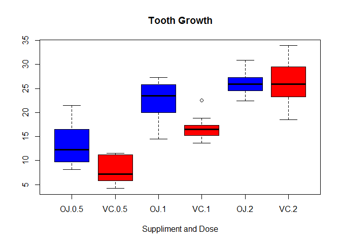

```r
ToothGrowth$dose <- as.factor(ToothGrowth$dose)
boxplot(len~supp*dose, data=ToothGrowth,col=(c("blue","red")),main="Tooth Growth", xlab="Suppliment and Dose")
```

#### 2.Provide a basic summary of the data.

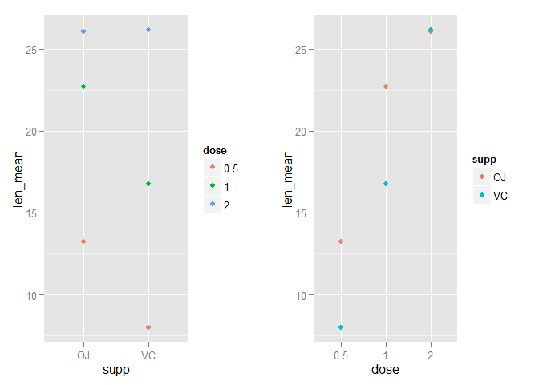

```r
n_by_type<-aggregate(ToothGrowth$len, list(ToothGrowth$supp,ToothGrowth$dose), length)
mean_by_type<-aggregate(ToothGrowth$len, list(ToothGrowth$supp,ToothGrowth$dose), mean)
names(mean_by_type)<-c("supp","dose","len_mean")
sd_by_type<-aggregate(ToothGrowth$len, list(ToothGrowth$supp,ToothGrowth$dose), sd)
names(sd_by_type)<-c("supp","dose","len_sd")
mean_by_supp <- qplot(supp,len_mean, data = mean_by_type,color = dose)
mean_by_dose<- qplot(dose,len_mean, data = mean_by_type,color = supp)
grid.arrange(mean_by_supp, mean_by_dose, ncol = 2)
```

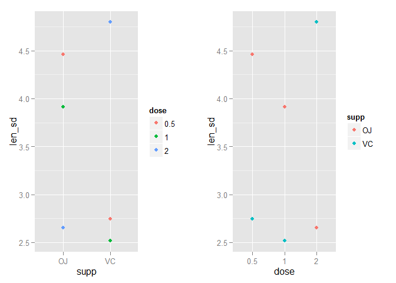

```r
sd_by_supp <- qplot(supp,len_sd, data = sd_by_type,color = dose)
sd_by_dose<- qplot(dose,len_sd, data = sd_by_type,color = supp)
grid.arrange(sd_by_supp, sd_by_dose, ncol = 2)
```

#### 3.Use confidence intervals and/or hypothesis tests to compare tooth growth by supp and dose. (Only use the techniques from class, even if there’s other approaches worth considering)

##### Compare tooth growth by supplement

```r
t.test(len ~ supp, paired = F, var.equal = F, data = ToothGrowth)
```

```
##
##  Welch Two Sample t-test
##
## data:  len by supp
## t = 1.9153, df = 55.309, p-value = 0.06063
## alternative hypothesis: true difference in means is not equal to 0
## 95 percent confidence interval:
##  -0.1710156  7.5710156
## sample estimates:
## mean in group OJ mean in group VC
##         20.66333         16.96333
```

Since 0 is in the conf. interval we can’t say for sure that there is a difference in tooth len among the two supplements. Another support for this is |t| value less than 2.

##### Compare tooth growth by dose

```r
t.test(len ~ dose, paired = F, var.equal = F, data = subset(ToothGrowth,ToothGrowth$dose!="0.5"))
```

```
##
##  Welch Two Sample t-test
##
## data:  len by dose
## t = -4.9005, df = 37.101, p-value = 1.906e-05
## alternative hypothesis: true difference in means is not equal to 0
## 95 percent confidence interval:
##  -8.996481 -3.733519
## sample estimates:
## mean in group 1 mean in group 2
##          19.735          26.100
```

Since 0 is not in the conf. interval it’s safe to assume that dosage of 1 vs. 2 does have influence on tooth len. Another support for this is |t| value which is high enough.

```r
t.test(len ~ dose, paired = F, var.equal = F, data = subset(ToothGrowth,ToothGrowth$dose!="1"))
```

```
##
##  Welch Two Sample t-test
##
## data:  len by dose
## t = -11.799, df = 36.883, p-value = 4.398e-14
## alternative hypothesis: true difference in means is not equal to 0
## 95 percent confidence interval:
##  -18.15617 -12.83383
## sample estimates:
## mean in group 0.5   mean in group 2
##            10.605            26.100
```

Since 0 is not in the conf. interval it’s safe to assume that dosage of 0.5 vs. 2 does have influence on tooth len. Another support for this is |t| value which is high enough.

```r
t.test(len ~ dose, paired = F, var.equal = F, data = subset(ToothGrowth,ToothGrowth$dose!="2"))
```

```
##
##  Welch Two Sample t-test
##
## data:  len by dose
## t = -6.4766, df = 37.986, p-value = 1.268e-07
## alternative hypothesis: true difference in means is not equal to 0
## 95 percent confidence interval:
##  -11.983781  -6.276219
## sample estimates:
## mean in group 0.5   mean in group 1
##            10.605            19.735
```

Since 0 is not in the conf. interval it’s safe to assume that dosage of 0.5 vs. 1 does have influence on tooth len. Another support for this is |t| value which is high enough.

#### 4. State your conclusions and the assumptions needed for your conclusions.

Generally speaking we’ve seen that supplement type probably does not have a big influence on tooth growth while dosage does have an impact(though it seems that orange juice does generates longer len teeth in average but it’s not enough to conclude it as a better supplement) . The bigger the dosage is , the longer the teeth are.

The following assumptions were made : 1. The variance of all tested groups are different . 2. The tested groups are not paired (meaning it’s not same subjects with getting both supplements or all the dosages). 3. Since the number of tested subjects is relatively small , we assume it’s random enough to be used as testing subjects